# Class 3/Lab1: Subset Selection and Shrinkage

Week 3 (9.11)

## Introduction

In this lab, we will:

1. Fit a simple linear regression baseline and interpret its coefficients and prediction intervals.
2. Compare best subset, forward stepwise, and backward stepwise selection on the `insurance` dataset.
3. Fit ridge and lasso regression, and visualize how their coefficient paths differ as the penalty grows.

```r
# Clear environment and unload packages
rm(list = ls())
pacman::p_unload(pacman::p_loaded())

# Load necessary packages
pacman::p_load(tidyverse, leaps, glmnet, patchwork, here, latex2exp)
```

### Simple Linear Regression Baseline

Before comparing selection methods, it’s worth fitting the simplest possible model: one predictor, ordinary least squares. We’ll use the `neonatal_brain_volumes` dataset to relate gestational age (`GA`) to brain volume.

```r
brain_data <- read_csv(file.path(here(), "lectures", "03-regression-1", "data", "neonatal_brain_volumes.csv"))
head(brain_data)
```

```
## # A tibble: 6 × 2
##      GA `brain volume`
##   <dbl>          <dbl>
## 1  35.7           252.
## 2  37.4           278.
## 3  36.1           266.
## 4  36.7           266.
## 5  42.3           308.
## 6  40.1           304.
```

```r
slr_fit <- lm(`brain volume` ~ GA, data = brain_data)
summary(slr_fit)
```

```
##
## Call:
## lm(formula = `brain volume` ~ GA, data = brain_data)
##
## Residuals:
##     Min      1Q  Median      3Q     Max
## -95.486 -15.359   1.197  20.404  84.385
##
## Coefficients:
##             Estimate Std. Error t value Pr(>|t|)
## (Intercept) -445.289     25.699  -17.33   <2e-16 ***
## GA            19.647      0.688   28.56   <2e-16 ***
## ---
## Signif. codes:  0 '***' 0.001 '**' 0.01 '*' 0.05 '.' 0.1 ' ' 1
##
## Residual standard error: 33.63 on 160 degrees of freedom
## Multiple R-squared:  0.836,  Adjusted R-squared:  0.835
## F-statistic: 815.6 on 1 and 160 DF,  p-value: < 2.2e-16
```

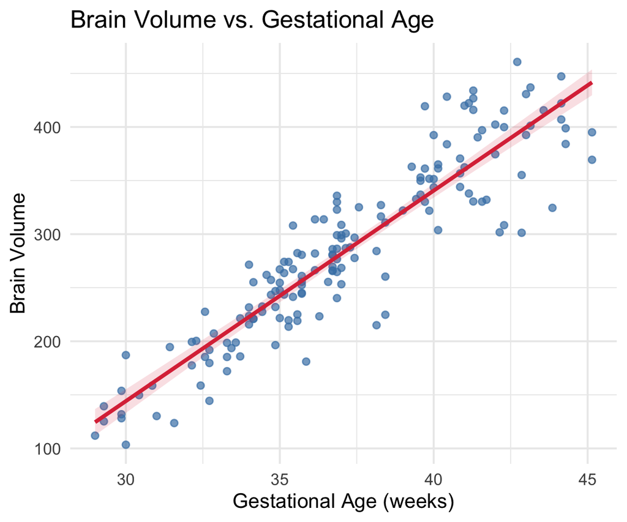

```r
ggplot(brain_data, aes(x = GA, y = `brain volume`)) +
  geom_point(alpha = 0.7, color = "steelblue") +
  geom_smooth(method = "lm", color = "#dc3545", fill = "#dc3545", alpha = 0.15) +
  labs(title = "Brain Volume vs. Gestational Age", x = "Gestational Age (weeks)", y = "Brain Volume") +
  theme_minimal(base_size = 14)
```

```r
confint(slr_fit, parm = "GA")
```

```
##       2.5 %   97.5 %
## GA 18.28867 21.00599
```

```r
new_ga <- data.frame(GA = mean(brain_data$GA))
predict(slr_fit, newdata = new_ga, interval = "confidence")
```

```
##        fit      lwr      upr
## 1 284.7462 279.5277 289.9647
```

```r
predict(slr_fit, newdata = new_ga, interval = "prediction")
```

```
##        fit      lwr      upr
## 1 284.7462 218.1206 351.3718
```

**Interpretation:** The confidence interval describes uncertainty about the *mean* brain volume at a given gestational age; the (wider) prediction interval describes uncertainty about a single *new* observation. Every method below is, at its core, still fitting a linear model like this one — just with a strategy for choosing which predictors belong in it.

### Subset Selection

With more than a couple of predictors, we need a systematic way to choose which ones to include. We’ll compare three approaches on the `insurance` dataset (predicting `charges` from the other columns).

```r
insurance <- read_csv(file.path(here(), "lectures", "03-regression-1", "data", "insurance.csv"))
head(insurance)
```

```
## # A tibble: 6 × 3
##   charges   age   bmi
##     <dbl> <dbl> <dbl>
## 1  16885.    19  27.9
## 2   1726.    18  33.8
## 3   4449.    28  33
## 4  21984.    33  22.7
## 5   3867.    32  28.9
## 6   3757.    31  25.7
```

```r
subset_formula <- charges ~ .

fit_best     <- regsubsets(subset_formula, data = insurance, nvmax = ncol(insurance) - 1)
fit_forward  <- regsubsets(subset_formula, data = insurance, nvmax = ncol(insurance) - 1, method = "forward")
fit_backward <- regsubsets(subset_formula, data = insurance, nvmax = ncol(insurance) - 1, method = "backward")
```

#### Which variables enter at each model size?

```r
summary(fit_best)$outmat
```

```
##          age bmi
## 1  ( 1 ) "*" " "
## 2  ( 1 ) "*" "*"
```

Each row is a model size; each `*` marks a predictor included at that size. Compare this to `summary(fit_forward)$outmat` and `summary(fit_backward)$outmat` — for a small predictor set like this one, the three methods often agree, but that’s not guaranteed in general (forward and backward selection are greedy and can miss the best subset that exhaustive search would find).

#### Choosing a model size

`regsubsets` reports RSS, adjusted $R^2$, and Mallows’ $C_p$ for every model size; we compute BIC ourselves from the selected variables at each step.

```r
calculate_bic <- function(model_obj, data) {
  s <- summary(model_obj)
  sapply(seq_len(nrow(s$outmat)), function(i) {
    vars <- names(which(s$outmat[i, ] == "*"))
    vars <- vars[vars != "(Intercept)"]
    fit <- lm(reformulate(vars, response = "charges"), data = data)
    BIC(fit)
  })
}

criteria_df <- data.frame(
  num_vars = seq_along(summary(fit_best)$rss),
  rss      = summary(fit_best)$rss,
  adjr2    = summary(fit_best)$adjr2,
  cp       = summary(fit_best)$cp,
  bic      = calculate_bic(fit_best, insurance)
)

criteria_df
```

```
##   num_vars          rss      adjr2       cp      bic
## 1        1 178544029385 0.08872432 43.00526 28851.55
## 2        2 173097580364 0.11586081  3.00000 28817.29
```

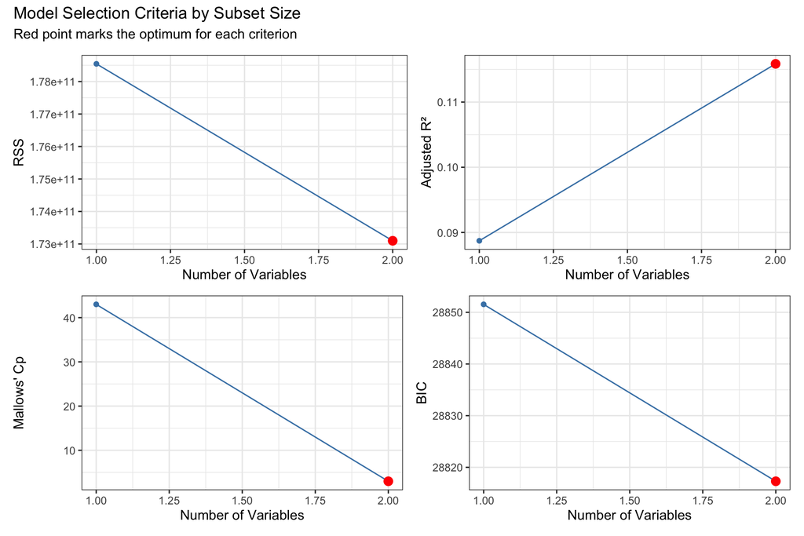

```r
p_adjr2 <- ggplot(criteria_df, aes(num_vars, adjr2)) +
  geom_line(color = "steelblue") + geom_point(color = "steelblue") +
  geom_point(data = criteria_df[which.max(criteria_df$adjr2), ], color = "red", size = 3) +
  labs(x = "Number of Variables", y = "Adjusted R²") + theme_bw()

p_cp <- ggplot(criteria_df, aes(num_vars, cp)) +
  geom_line(color = "steelblue") + geom_point(color = "steelblue") +
  geom_point(data = criteria_df[which.min(criteria_df$cp), ], color = "red", size = 3) +
  labs(x = "Number of Variables", y = "Mallows' Cp") + theme_bw()

p_bic <- ggplot(criteria_df, aes(num_vars, bic)) +
  geom_line(color = "steelblue") + geom_point(color = "steelblue") +
  geom_point(data = criteria_df[which.min(criteria_df$bic), ], color = "red", size = 3) +
  labs(x = "Number of Variables", y = "BIC") + theme_bw()

p_rss <- ggplot(criteria_df, aes(num_vars, rss)) +
  geom_line(color = "steelblue") + geom_point(color = "steelblue") +
  geom_point(data = criteria_df[which.min(criteria_df$rss), ], color = "red", size = 3) +
  labs(x = "Number of Variables", y = "RSS") + theme_bw()

(p_rss + p_adjr2) / (p_cp + p_bic) +
  plot_annotation(title = "Model Selection Criteria by Subset Size", subtitle = "Red point marks the optimum for each criterion")
```

### Ridge and Lasso Regression

Subset selection chooses a hard in/out for each predictor. Ridge and lasso instead *shrink* coefficients continuously, trading a little bias for a lot less variance. We’ll fit both on the same `insurance` data, using `age` and `bmi` as predictors of `charges`.

```r
x_vars <- insurance %>% select(age, bmi) %>% scale()
y_var  <- insurance$charges

ols_fit <- lm(charges ~ age + bmi, data = insurance %>% mutate(age = as.numeric(x_vars[, "age"]), bmi = as.numeric(x_vars[, "bmi"])))
coef(ols_fit)
```

```
## (Intercept)         age         bmi
##   13270.422    3399.118    2030.483
```

```r
ridge_fit <- glmnet(x_vars, y_var, alpha = 0)
lasso_fit <- glmnet(x_vars, y_var, alpha = 1)
```

#### Coefficient paths vs. $\lambda$

As $\lambda$ grows, ridge coefficients shrink smoothly toward zero but rarely hit it exactly; lasso coefficients can be driven to exactly zero, which is what makes it useful for variable selection.

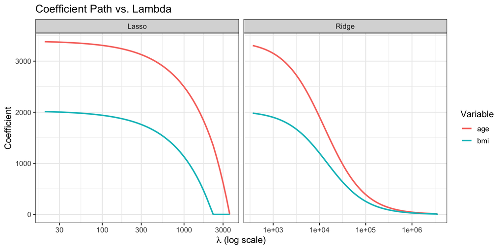

```r
tidy_path <- function(fit, model_name) {
  as.matrix(coef(fit)) %>%
    as.data.frame() %>%
    rownames_to_column("Variable") %>%
    pivot_longer(-Variable, names_to = "step", values_to = "Coefficient") %>%
    mutate(Lambda = fit$lambda[as.numeric(str_remove(step, "s")) + 1],
           Model = model_name) %>%
    filter(Variable != "(Intercept)")
}

path_df <- bind_rows(tidy_path(ridge_fit, "Ridge"), tidy_path(lasso_fit, "Lasso"))

ggplot(path_df, aes(x = Lambda, y = Coefficient, color = Variable)) +
  geom_line(linewidth = 1) +
  scale_x_log10() +
  facet_wrap(~Model, scales = "free_x") +
  labs(title = "Coefficient Path vs. Lambda", x = TeX("$\\lambda$ (log scale)"), y = "Coefficient") +
  theme_bw(base_size = 13)
```

#### Choosing $\lambda$ by cross-validation

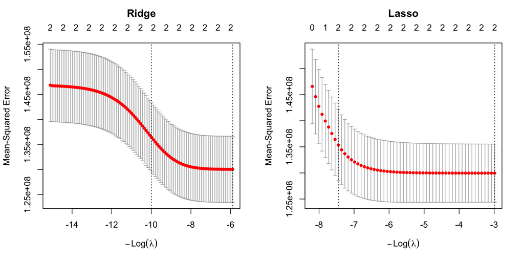

```r
set.seed(2155)
cv_ridge <- cv.glmnet(x_vars, y_var, alpha = 0)
cv_lasso <- cv.glmnet(x_vars, y_var, alpha = 1)

par(mfrow = c(1, 2))
plot(cv_ridge); title("Ridge", line = 2.5)
plot(cv_lasso); title("Lasso", line = 2.5)
```

```r
par(mfrow = c(1, 1))
```

```r
cat("Ridge coefficients at lambda.min:\n")
```

```
## Ridge coefficients at lambda.min:
```

```r
coef(cv_ridge, s = "lambda.min")
```

```
## 3 x 1 sparse Matrix of class "dgCMatrix"
##             lambda.min
## (Intercept)  13270.422
## age           3305.635
## bmi           1981.451
```

```r
cat("\nLasso coefficients at lambda.min:\n")
```

```
##
## Lasso coefficients at lambda.min:
```

```r
coef(cv_lasso, s = "lambda.min")
```

```
## 3 x 1 sparse Matrix of class "dgCMatrix"
##             lambda.min
## (Intercept)  13270.422
## age           3381.290
## bmi           2012.653
```

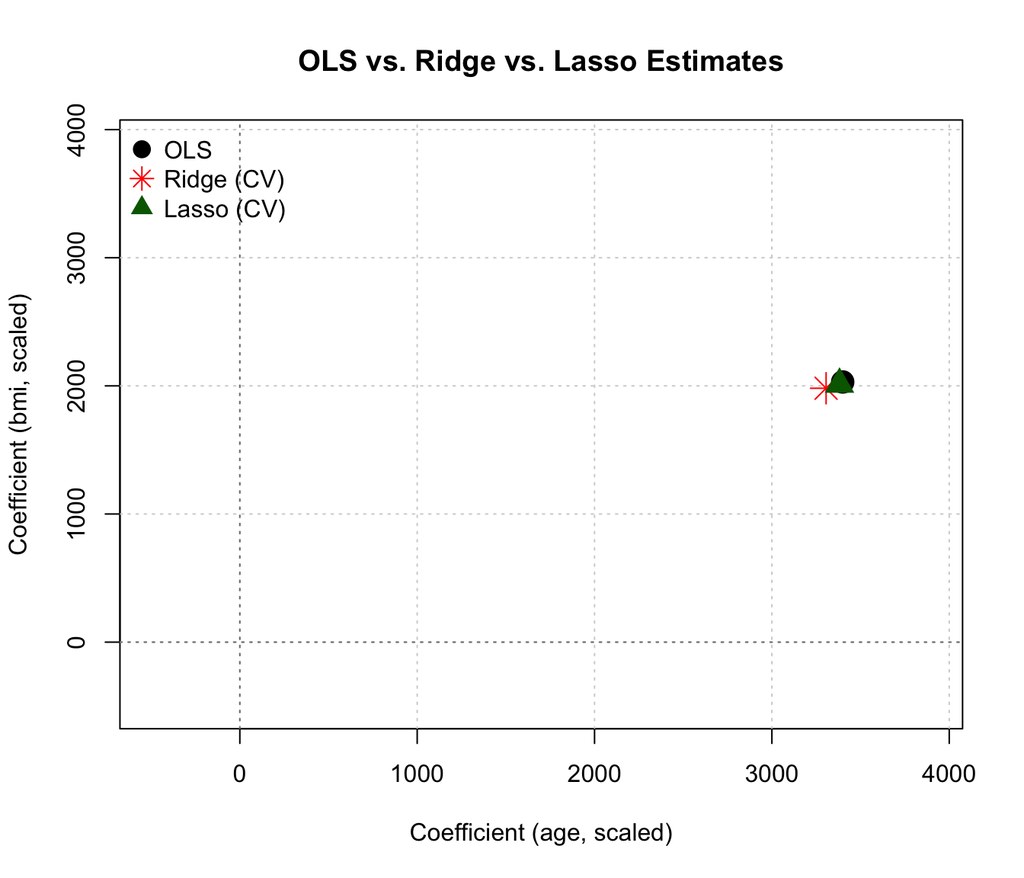

```r
ridge_coefs <- as.vector(coef(cv_ridge, s = "lambda.min"))[-1]
lasso_coefs <- as.vector(coef(cv_lasso, s = "lambda.min"))[-1]
ols_coefs   <- coef(ols_fit)[-1]

xlim <- range(c(ridge_coefs, lasso_coefs, ols_coefs, 0)) + c(-500, 500)
ylim <- xlim

plot(0, 0, type = "n", xlim = xlim, ylim = ylim,
     xlab = "Coefficient (age, scaled)", ylab = "Coefficient (bmi, scaled)",
     main = "OLS vs. Ridge vs. Lasso Estimates")
grid()
abline(h = 0, lty = 3, col = "gray50"); abline(v = 0, lty = 3, col = "gray50")

points(ols_coefs[1], ols_coefs[2], pch = 19, cex = 2, col = "black")
points(ridge_coefs[1], ridge_coefs[2], pch = 8, cex = 2, col = "red")
points(lasso_coefs[1], lasso_coefs[2], pch = 17, cex = 2, col = "darkgreen")

legend("topleft", legend = c("OLS", "Ridge (CV)", "Lasso (CV)"),
       col = c("black", "red", "darkgreen"), pch = c(19, 8, 17), pt.cex = 1.5, bty = "n")
```

**Interpretation:** Ridge and lasso estimates sit closer to the origin than the unpenalized OLS estimate — both are trading a small amount of bias for reduced variance. The shape of the constraint region each method implicitly enforces (a circle for ridge, a diamond for lasso) is what makes lasso capable of setting coefficients to exactly zero, since the diamond’s corners lie on the axes.